## **Información geográfica y mapas**

```r
radios <- st_read("https://bitsandbricks.github.io/data/CABA_rc.geojson")
summary(radios)
```

```
    RADIO_ID          BARRIO         COMUNA       POBLACION        VIVIENDAS
 1_1_1  :   1   PALERMO  : 295   1      : 329   Min.   :   0.0   Min.   :   0.0
 1_10_1 :   1   CABALLITO: 215   13     : 305   1st Qu.: 646.2   1st Qu.: 311.2
 1_10_10:   1   RECOLETA : 198   14     : 295   Median : 786.0   Median : 377.0
 1_10_11:   1   BALVANERA: 191   3      : 254   Mean   : 813.2   Mean   : 401.4
 1_10_12:   1   FLORES   : 183   4      : 252   3rd Qu.: 928.0   3rd Qu.: 462.0
 1_10_13:   1   BELGRANO : 170   7      : 250   Max.   :3945.0   Max.   :1405.0
 (Other):3548   (Other)  :2302   (Other):1869
    HOGARES        HOGARES_NBI        AREA_KM2                 geometry
 Min.   :   0.0   Min.   :  0.00   Min.   :0.004468   MULTIPOLYGON :3554
 1st Qu.: 259.0   1st Qu.:  2.00   1st Qu.:0.018626   epsg:4326    :   0
 Median : 310.0   Median :  6.00   Median :0.035548   +proj=long...:   0
 Mean   : 323.6   Mean   : 19.35   Mean   :0.057350
 3rd Qu.: 371.0   3rd Qu.: 23.00   3rd Qu.:0.062847
 Max.   :1093.0   Max.   :403.00   Max.   :3.804422
```

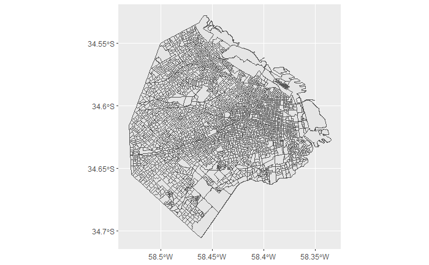

```r
ggplot() + geom_sf(data = radios)
```

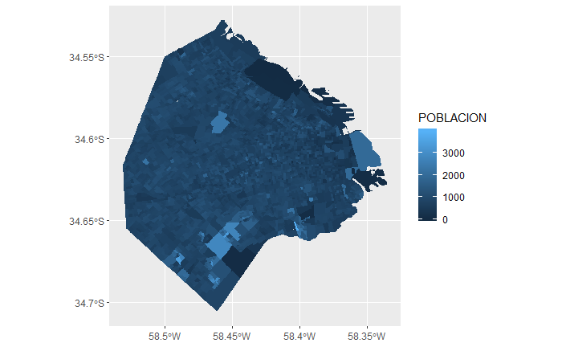

```r
ggplot() + geom_sf(data = radios, aes(fill = POBLACION), color = NA)
```

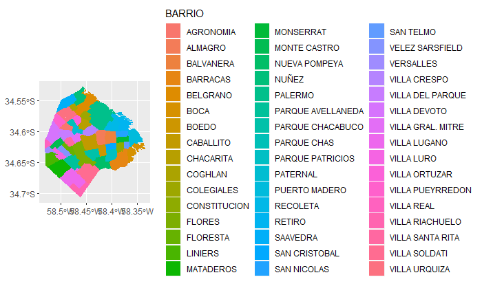

```r
ggplot() + geom_sf(data = radios, aes(fill = BARRIO), color = NA)
```

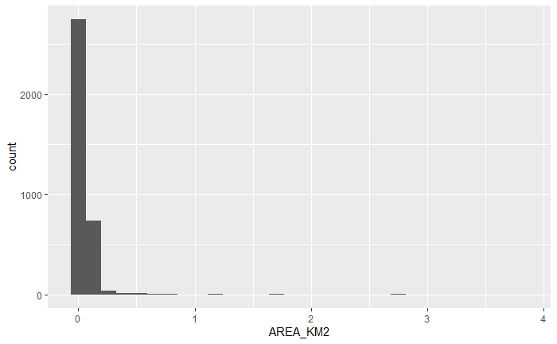

```r
ggplot() + geom_histogram(data = radios, aes(x = AREA_KM2))
```

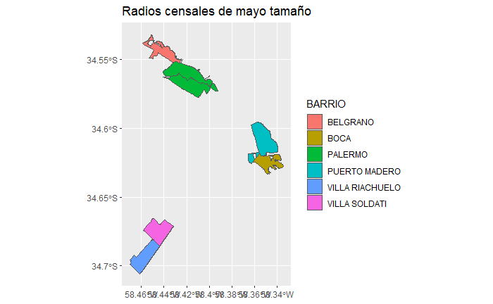

```r
filtrados <- radios %>%
    filter(AREA_KM2 > 2)

ggplot() +
    geom_sf(data = filtrados, aes(fill = BARRIO)) +
    labs(title = "Radios censales de mayo tamaño")
```

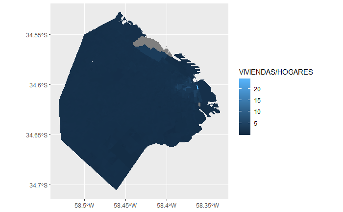

```r
ggplot() + geom_sf(data = radios, aes(fill = VIVIENDAS/HOGARES), color = NA)
```

Hay un radio censal que parece brillar, destacándose entre los demás. ¿Dónde está? Esta vez lo resolvemos en forma analítica en lugar de visual, usando los verbos de transformación de datos. Vamos a definir una variable nueva, con la tasa entre viviendas y hogares que ya usamos para el gráfico. Luego vamos a ordenar el dataframe por orden descendiente de la tasa, y usando `head()` nos quedamos sólo con los primeros valores, que corresponden a los más altos:

```r
radios %>%
    mutate(viv_vs_hogares = VIVIENDAS / HOGARES) %>%
    arrange(desc(viv_vs_hogares)) %>%
    head()
```

```
Simple feature collection with 6 features and 9 fields
geometry type:  MULTIPOLYGON
dimension:      XY
bbox:           xmin: -58.38038 ymin: -34.62205 xmax: -58.35869 ymax: -34.60085
epsg (SRID):    4326
proj4string:    +proj=longlat +datum=WGS84 +no_defs
  RADIO_ID        BARRIO COMUNA POBLACION VIVIENDAS HOGARES HOGARES_NBI
1  1_13_15 PUERTO MADERO      1         0         6       0           0
2   1_13_3 PUERTO MADERO      1        45       473      20           0
3   1_9_19   SAN NICOLAS      1       119       405      61           6
4  1_12_10   SAN NICOLAS      1       296       629     101           1
5  1_12_12   SAN NICOLAS      1       499       471      90          17
6   1_9_15   SAN NICOLAS      1       238       608     118          13
    AREA_KM2 viv_vs_hogares                       geometry
1 0.07899011            Inf MULTIPOLYGON (((-58.36131 -...
2 0.05698617      23.650000 MULTIPOLYGON (((-58.36094 -...
3 0.06236044       6.639344 MULTIPOLYGON (((-58.37606 -...
4 0.04438025       6.227723 MULTIPOLYGON (((-58.37879 -...
5 0.03108456       5.233333 MULTIPOLYGON (((-58.37879 -...
6 0.03287564       5.152542 MULTIPOLYGON (((-58.37473 -...
```

En lugar de mostrar “número de crímenes por barrio” es más instructivo mostrar el número de crímenes per cápita; de lo contrario es de esperar que los lugares más poblados siempre estén a la cabeza, lo cual no agrega demasiada información.  
En lugar de mostrar “cantidad de habitantes por radio censal”, suele preferirse mostrar la densidad de población, es decir la cantidad de habitantes dividida por la extensión del área. Los mapas de densidad muestran mucho mejor la distribución espacial de la población.

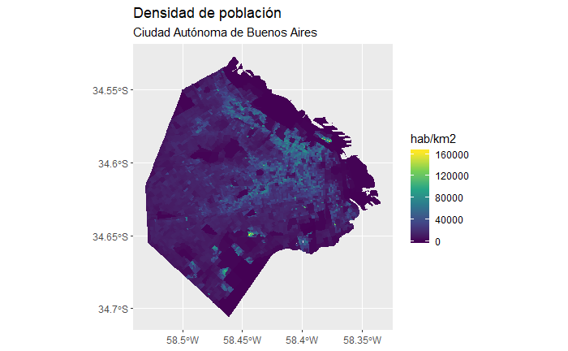

```r
ggplot() +
    geom_sf(data = radios, aes(fill = POBLACION/AREA_KM2), color = NA) +
    scale_fill_viridis_c() +
    labs(title = "Densidad de población",
         subtitle = "Ciudad Autónoma de Buenos Aires",
         fill = "hab/km2")
```

Este último gráfico representa de forma mucho mas precisa la distribución de habitantes en la ciudad, haciendo saltar a la vista los núcleos con mayor densidad de población. De paso, aprendimos un truco nuevo: agregando `scale_fill_viridis_c()` le pedimos a ggplot que utilice la escala de colores conocida como “viridis”, diseñada por expertos en visualización para ser fácil de leer… y lucir bien.

### **Volcando en el mapa información de múltiples fuentes**

```r
atencion_ciudadano <- read.csv("http://bitsandbricks.github.io/data/gcba_suaci_comunas.csv")
names(atencion_ciudadano)
```

```
[1] "PERIODO"         "RUBRO"           "TIPO_PRESTACION" "BARRIO"
[5] "total"           "COMUNA"
```

```r
names(radios)
```

```
[1] "RADIO_ID"    "BARRIO"      "COMUNA"      "POBLACION"   "VIVIENDAS"
[6] "HOGARES"     "HOGARES_NBI" "AREA_KM2"    "geometry"
```

```r
barrios_geo <- radios %>%
    group_by(BARRIO) %>%
    summarise(POBLACION = sum(POBLACION),
              VIVIENDAS = sum(VIVIENDAS),
              HOGARES = sum(HOGARES),
              HOGARES_NBI = sum(HOGARES_NBI),
              AREA_KM2 = sum(AREA_KM2))
```

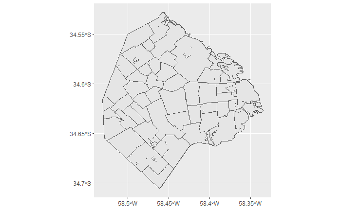

```r
ggplot() + geom_sf(data = barrios_geo)
```

```r
atencion_por_barrio <- atencion_ciudadano %>%
    group_by(BARRIO) %>%
    summarise(total = sum(total))

head(atencion_por_barrio, 500)
```

| BARRIO | total |
| --- | --- |
|  | 5722 |
| AGRONOMIA | 9604 |
| ALMAGRO | 54190 |
| BALVANERA | 49540 |
| BARRACAS | 31752 |
| BELGRANO | 56522 |
| BOCA | 15478 |
| BOEDO | 22881 |
| CABALLITO | 82790 |
| CHACARITA | 17170 |

[output cut: 41 more lines]

```r
barrios_geo <- barrios_geo %>% left_join(atencion_por_barrio)
```

```
Column `BARRIO` joining factors with different levels, coercing to character vector
```

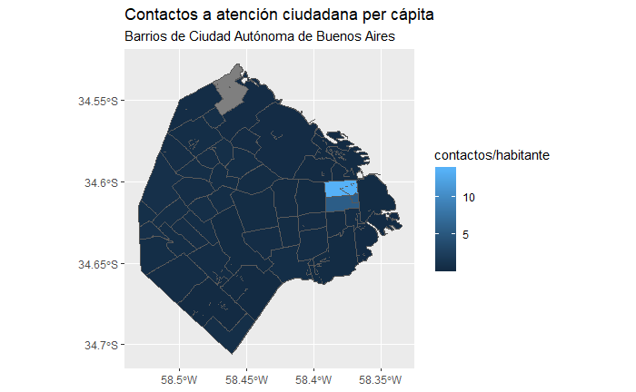

```r
ggplot() +
    geom_sf(data = barrios_geo, aes(fill = total/POBLACION)) +
    labs(title = "Contactos a atención ciudadana per cápita",
         subtitle = "Barrios de Ciudad Autónoma de Buenos Aires",
         fill = "contactos/habitante")
```

Usando los verbos de transformación que conocemos, la receta sería:  
1. Agrupar los datos por barrio y por rubro  
2. Crear un resumen con el total de contactos por rubro en cada barrio  
3. Por cada grupo, filtrar los datos para conservar sólo el rubro que tiene la cantidad más grande de contactos

```r
atencion_por_barrio_principal_rubro <- atencion_ciudadano %>%
    group_by(BARRIO, RUBRO) %>%
    summarise(contactos = sum(total)) %>%
    filter(contactos == max(contactos))

head(atencion_por_barrio_principal_rubro, 400)
```

| BARRIO | RUBRO | contactos |
| --- | --- | --- |
|  | REGISTRO CIVIL | 5004 |
| AGRONOMIA | SANEAMIENTO URBANO | 4691 |
| ALMAGRO | SANEAMIENTO URBANO | 22429 |
| BALVANERA | SANEAMIENTO URBANO | 16840 |
| BARRACAS | SANEAMIENTO URBANO | 10138 |
| BELGRANO | SANEAMIENTO URBANO | 21060 |
| BOCA | SANEAMIENTO URBANO | 4151 |
| BOEDO | SANEAMIENTO URBANO | 9382 |
| CABALLITO | SANEAMIENTO URBANO | 36216 |
| CHACARITA | SANEAMIENTO URBANO | 6365 |

[output cut: 41 more lines]

```r
barrios_geo <- barrios_geo %>% left_join(atencion_por_barrio_principal_rubro)
```

```
Column `BARRIO` joining character vector and factor, coercing into character vector
```

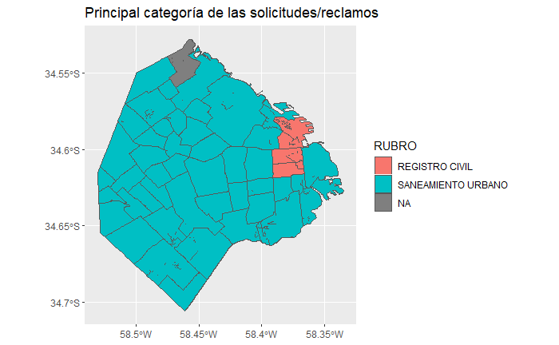

```r
ggplot() +
    geom_sf(data = barrios_geo, aes(fill = RUBRO)) +
    labs(title = "Principal categoría de las solicitudes/reclamos")
```

### Combinando capas geográficas

```r
# las líneas de transporte subterráneo (SUBTE) de la ciudad
subte_lineas <- st_read("http://bitsandbricks.github.io/data/subte_lineas.geojson")
# y los puntos con las ubicaciones de las estaciones de SUBTE
subte_estaciones <- st_read("http://bitsandbricks.github.io/data/subte_estaciones.geojson")
```

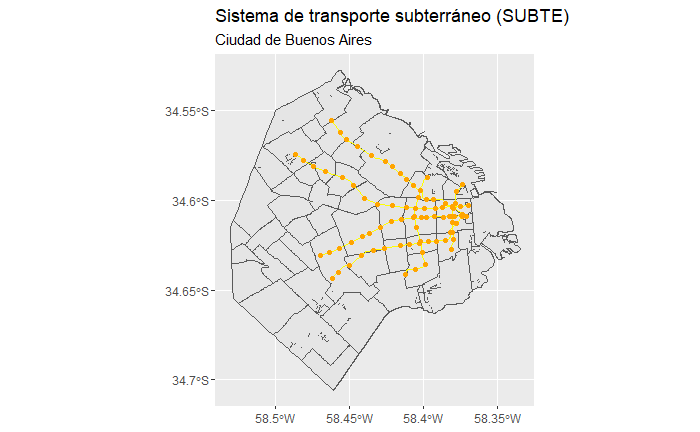

```r
ggplot() +
    geom_sf(data = barrios_geo) +
    geom_sf(data = subte_lineas, color = "yellow") +
    geom_sf(data = subte_estaciones, color = "orange") +
    labs(title = "Sistema de transporte subterráneo (SUBTE)",
         subtitle = "Ciudad de Buenos Aires")
```

```r
emergencias_en_subte <- atencion_ciudadano %>%
    filter(RUBRO == "EMERGENCIAS EN SUBTE") %>%
    group_by(BARRIO) %>%
    summarise(emergencias = sum(total))

barrios_geo <- barrios_geo %>% left_join(emergencias_en_subte)
```

```
Column `BARRIO` joining character vector and factor, coercing into character vector
```

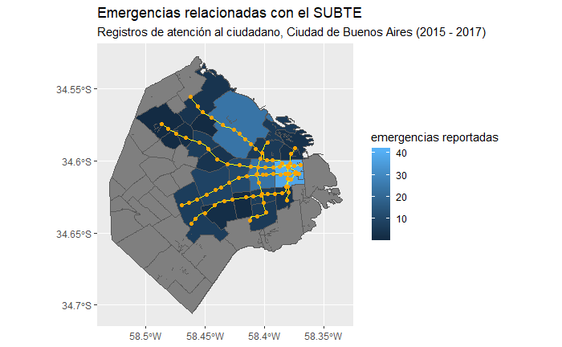

```r
ggplot() +
    geom_sf(data = barrios_geo, aes(fill = emergencias)) +
    geom_sf(data = subte_lineas, color = "yellow") +
    geom_sf(data = subte_estaciones, color = "orange") +
    labs(title = "Emergencias relacionadas con el SUBTE",
         subtitle = "Registros de atención al ciudadano, Ciudad de Buenos Aires (2015 - 2017)",
         fill = "emergencias reportadas")
```

> Aquí se cumplen las expectativas: la cantidad de emergencias reportadas sigue en forma clara un patrón relacionado con la cantidad de estaciones ubicadas en cada barrio. Y como era de esperarse, en barrios donde el SUBTE no ofrece cobertura la cantidad de emergencias es nula.